# Reproducible Research: Peer Assessment 1

angieFelipe

13/2/2018

## Loading and preprocessing the data

First I will load the required packages

```r
paq<-c("dplyr","ggplot2","readr" )

lapply(paq, function(paq) {if (!require(paq, character.only=T))
{install.packages(paq);require(paq)}})
```

We unzip the data and read it.

```r
zipF<- "activity.zip"
        unzip(zipF,overwrite = TRUE)

dataF<-"activity.csv"
        activity<-read_csv(dataF)
str(activity)
```

```
## Classes 'tbl_df', 'tbl' and 'data.frame':    17568 obs. of  3 variables:
##  $ steps   : int  NA NA NA NA NA NA NA NA NA NA ...
##  $ date    : Date, format: "2012-10-01" "2012-10-01" ...
##  $ interval: int  0 5 10 15 20 25 30 35 40 45 ...
##  - attr(*, "spec")=List of 2
##   ..$ cols   :List of 3
##   .. ..$ steps   : list()
##   .. .. ..- attr(*, "class")= chr  "collector_integer" "collector"
##   .. ..$ date    :List of 1
##   .. .. ..$ format: chr ""
##   .. .. ..- attr(*, "class")= chr  "collector_date" "collector"
##   .. ..$ interval: list()
##   .. .. ..- attr(*, "class")= chr  "collector_integer" "collector"
##   ..$ default: list()
##   .. ..- attr(*, "class")= chr  "collector_guess" "collector"
##   ..- attr(*, "class")= chr "col_spec"
```

## What is mean total number of steps taken per day?

In this part we will ignore the missing values in the dataset.

1. Make a histogram of the total number of steps taken each day

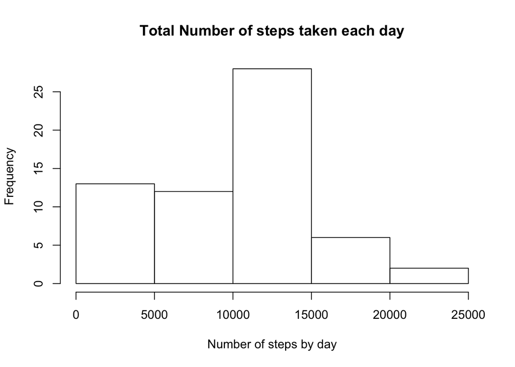

```r
hist1<-activity %>% group_by(date) %>% summarise(s_steps=sum(steps,na.rm=T))
with(hist1, hist(s_steps, main = "Total Number of steps taken each day",
     xlab = "Number of steps by day"))
```

2. Calculate and report the **mean** and **median** total number of steps taken per day

```r
with_na <- c(mean=round(mean(hist1$s_steps),2), median = round(median(hist1$s_steps),2))
with_na
```

```
##     mean   median
##  9354.23 10395.00
```

## What is the average daily activity pattern?

1. Make a time series plot (i.e. `type = "l"`) of the 5-minute interval (x-axis) and the average number of steps taken, averaged across all days (y-axis)

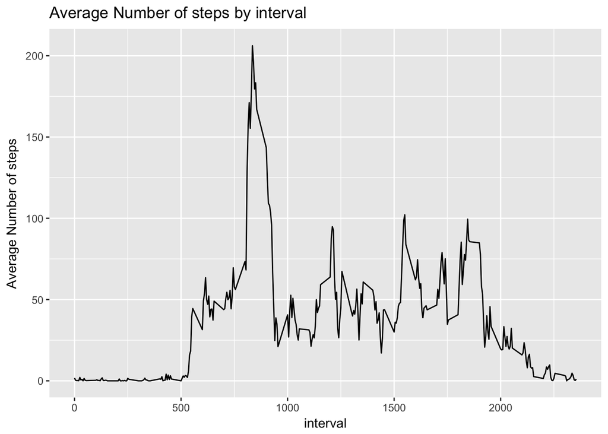

```r
plot1<-activity %>% group_by(interval) %>% summarise(a_steps=mean(steps,na.rm=T))
ggplot(plot1,aes(x=interval,y=a_steps) )+
        geom_line()+
        labs(title = "Average Number of steps by interval",
             y = "Average Number of steps")
```

2. Which 5-minute interval, on average across all the days in the dataset, contains the maximum number of steps?

```r
maxint <- plot1[plot1$a_steps == max(plot1$a_steps),1]
```

The interval is 835

## Imputing missing values

1. Calculate and report the total number of missing values in the dataset (i.e. the total number of rows with `NA`s)

Ther are only missing values in the variable steps.

```r
activity$na <- is.na(activity$steps)
na <- sum(activity$na)
pct <- round(mean(activity$na)*100,2)
```

The total number of missing values in the dataset is 2304 which represents a 13.11 % of total observations.

2. Devise a strategy for filling in all of the missing values in the dataset. The strategy does not need to be sophisticated. For example, you could use the mean/median for that day, or the mean for that 5-minute interval, etc.

For filling the missing values I will use the mean for that 5-minute interval in all days

3. Create a new dataset that is equal to the original dataset but with the missing data filled in.

```r
plot1<-as.data.frame(plot1)
activity2<-as.data.frame(activity)
for (i in seq(1:nrow(activity2))){
        if (activity2[i,4]==TRUE){
                activity2[i,1]=plot1[plot1$interval==activity2[i,3],2]
        }
}

newna <- sum(is.na(activity2$steps))
newna
```

```
## [1] 0
```

In the new dataset **activity2** total na are 0.

4. Make a histogram of the total number of steps taken each day and Calculate and report the **mean** and **median** total number of steps taken per day.

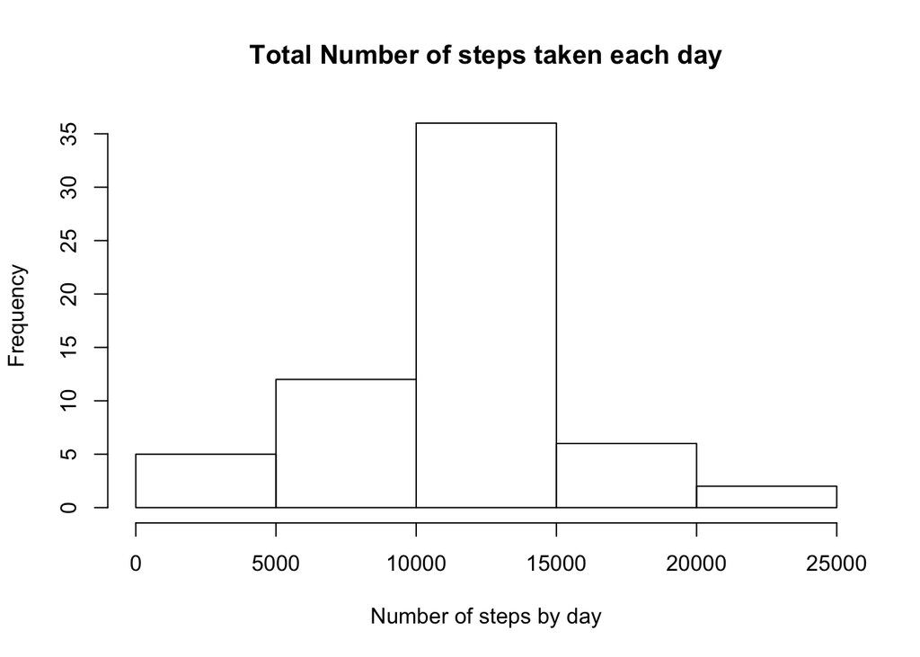

```r
hist2<-activity2 %>% group_by(date) %>% summarise(s_steps=sum(steps,na.rm=T))
with(hist2, hist(s_steps, main = "Total Number of steps taken each day",
                 xlab = "Number of steps by day"))
```

```r
without_na <- c(mean=round(mean(hist2$s_steps),2), median = round(median(hist2$s_steps),2))
without_na
```

```
##     mean   median
## 10766.19 10766.19
```

*Do these values differ from the estimates from the first part of the assignment?*

```r
table<-cbind(with_na,without_na)
table
```

```
##         with_na without_na
## mean    9354.23   10766.19
## median 10395.00   10766.19
```

Both, mean and median have increase to the same value

*What is the impact of imputing missing data on the estimates of the total daily number of steps?*

The distribution of steps by day is now more simetric and the mean and median are equal

## Are there differences in activity patterns between weekdays and weekends?

1. Create a new factor variable in the dataset with two levels – “weekday” and “weekend” indicating whether a given date is a weekday or weekend day.

```r
activity2$wd<-weekdays(activity2$date)
wend <- unique(weekdays(activity2$date))[6:7]

for (i in seq(1:nrow(activity2))){
        if (activity2[i,5] %in% wend){
                activity2[i,5]="weekend"
        }
        else {
                activity2[i,5]="weekday"
        }
}

activity2$wd <- as.factor(activity2$wd)

str(activity2$wd)
```

```
##  Factor w/ 2 levels "weekday","weekend": 1 1 1 1 1 1 1 1 1 1 ...
```

1. Make a panel plot containing a time series plot (i.e. `type = "l"`) of the 5-minute interval (x-axis) and the average number of steps taken, averaged across all weekday days or weekend days (y-axis).

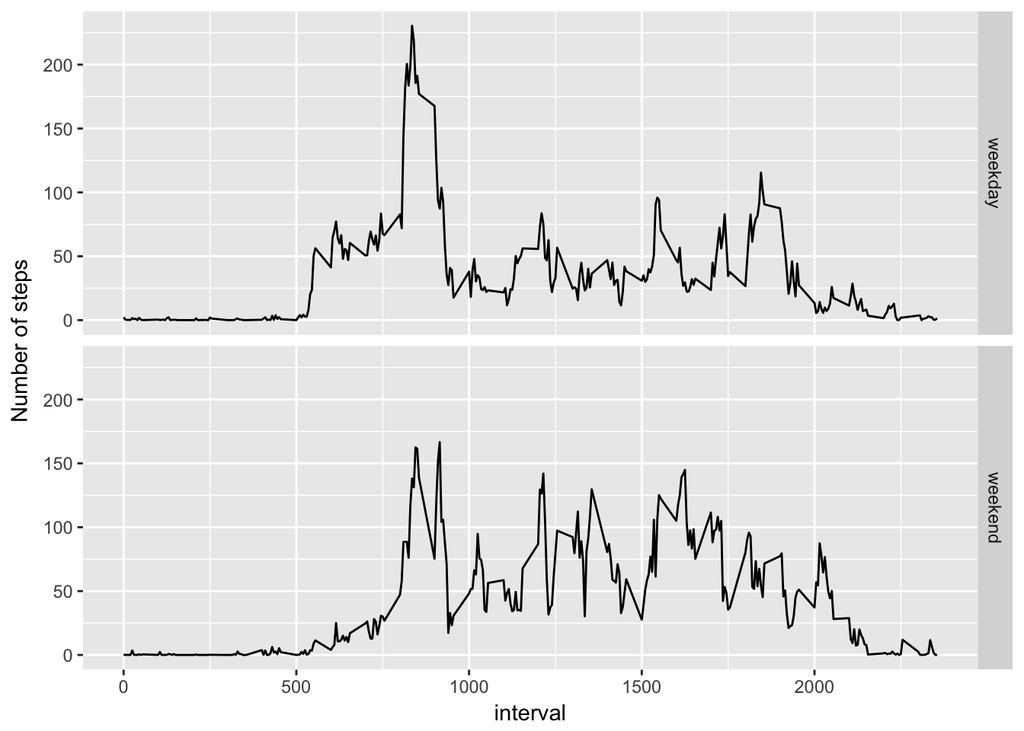

```r
plot3 <- activity2 %>% group_by(wd,interval) %>%                         summarise(a_steps=mean(steps,na.rm=T))

ggplot(plot3, aes(x=interval, y=a_steps))+
        geom_line()+
        facet_grid(wd~.)+
        labs(y="Number of steps")
```

It looks as if there would be a different pattern in average steps by interval depending on weekdays or weekend.